# PREDICTION OF NEXT WEEK'S COVID 19 DEATHS BASED ON THIS WEEK'S DATA

# II. PRE-PROCESSING

#### Creation of the training and validation(first test) dataset

```python
from sklearn.model_selection import train_test_split
```

```python
dataf = data.copy()
```

```python
dataf.head(5)
```

|  | Id | Location | Weekly Cases | Year | Weekly Cases per Million | Weekly Deaths | Weekly Deaths per Million | Total Vaccinations | People Vaccinated | People Fully Vaccinated | Total Boosters | Daily Vaccinations | Total Vaccinations per Hundred | People Vaccinated per Hundred | People Fully Vaccinated per Hundred | Total Boosters per Hundred | Daily Vaccinations per Hundred | Daily People Vaccinated | Daily People Vaccinated per Hundred | Next Week's Deaths |
| --- | --- | --- | --- | --- | --- | --- | --- | --- | --- | --- | --- | --- | --- | --- | --- | --- | --- | --- | --- | --- |
| 0 | 911530868 | World | 2372.0 | 2020 | 0.300 | 65.0 | 0.008 | NaN | NaN | NaN | NaN | NaN | NaN | NaN | NaN | NaN | NaN | NaN | NaN | 344.0 |
| 1 | 807936902 | World | 5023.0 | 2020 | 0.635 | 114.0 | 0.014 | NaN | NaN | NaN | NaN | NaN | NaN | NaN | NaN | NaN | NaN | NaN | NaN | 361.0 |
| 2 | 773590408 | World | 5612.0 | 2020 | 0.710 | 116.0 | 0.015 | NaN | NaN | NaN | NaN | NaN | NaN | NaN | NaN | NaN | NaN | NaN | NaN | 431.0 |
| 3 | 130466459 | World | 7580.0 | 2020 | 0.958 | 153.0 | 0.019 | NaN | NaN | NaN | NaN | NaN | NaN | NaN | NaN | NaN | NaN | NaN | NaN | 463.0 |
| 4 | 544040446 | World | 8983.0 | 2020 | 1.136 | 187.0 | 0.024 | NaN | NaN | NaN | NaN | NaN | NaN | NaN | NaN | NaN | NaN | NaN | NaN | 506.0 |

```python
train_set, val_set = train_test_split(dataf, test_size=0.3, random_state=0 )
```

```python
print(f"The size of the train_set : {train_set.shape}")
print(f"The size of the Val_set : {val_set.shape}")
```

```
The size of the train_set : (90409, 20)
The size of the Val_set : (38747, 20)
```

#### Encoding, Standardization, etc..

```python
for col in dataf.select_dtypes('object'):
    print(f'{col :-<50} \n\n{dataf[col].unique()}')
```

```
Location------------------------------------------

['World' 'Afghanistan' 'Africa' 'Albania' 'Algeria' 'Andorra' 'Angola'
 'Anguilla' 'Antigua and Barbuda' 'Argentina' 'Armenia' 'Aruba' 'Asia'
 'Australia' 'Austria' 'Azerbaijan' 'Bahamas' 'Bahrain' 'Bangladesh'
 'Barbados' 'Belarus' 'Belgium' 'Belize' 'Benin' 'Bermuda' 'Bhutan'
 'Bolivia' 'Bonaire Sint Eustatius and Saba' 'Bosnia and Herzegovina'
 'Botswana' 'Brazil' 'British Virgin Islands' 'Brunei' 'Bulgaria'
 'Burkina Faso' 'Burundi' 'Cambodia' 'Cameroon' 'Canada' 'Cape Verde'
 'Cayman Islands' 'Central African Republic' 'Chad' 'Chile' 'China'
 'Colombia' 'Comoros' 'Congo' 'Cook Islands' 'Costa Rica' "Cote d'Ivoire"
 'Croatia' 'Cuba' 'Curacao' 'Cyprus' 'Czechia'
 'Democratic Republic of Congo' 'Denmark' 'Djibouti' 'Dominica'
 'Dominican Republic' 'Ecuador' 'Egypt' 'El Salvador' 'Equatorial Guinea'
 'Eritrea' 'Estonia' 'Eswatini' 'Ethiopia' 'Europe' 'European Union'
 'Faeroe Islands' 'Fiji' 'Finland' 'France' 'French Polynesia' 'Gabon'
 'Gambia' 'Georgia' 'Germany' 'Ghana' 'Gibraltar' 'Greece' 'Greenland'
 'Grenada' 'Guatemala' 'Guinea' 'Guinea-Bissau' 'Guyana' 'Haiti'
 'High income' 'Honduras' 'Hong Kong' 'Hungary' 'Iceland' 'India'
 'Indonesia' 'International' 'Iran' 'Iraq' 'Ireland' 'Isle of Man'
 'Israel' 'Italy' 'Jamaica' 'Japan' 'Jordan' 'Kazakhstan' 'Kenya'
 'Kiribati' 'Kosovo' 'Kuwait' 'Kyrgyzstan' 'Laos' 'Latvia' 'Lebanon'
 'Lesotho' 'Liberia' 'Libya' 'Liechtenstein' 'Lithuania' 'Low income'
 'Lower middle income' 'Luxembourg' 'Macao' 'Madagascar' 'Malawi'
 'Malaysia' 'Maldives' 'Mali' 'Malta' 'Mauritania' 'Mauritius' 'Mexico'
 'Moldova' 'Monaco' 'Mongolia' 'Montenegro' 'Montserrat' 'Morocco'
 'Mozambique' 'Myanmar' 'Namibia' 'Nepal' 'Netherlands' 'New Caledonia'
 'New Zealand' 'Nicaragua' 'Niger' 'Nigeria' 'North America' 'North Korea'
 'North Macedonia' 'Norway' 'Oceania' 'Oman' 'Pakistan' 'Palau'
 'Palestine' 'Panama' 'Papua New Guinea' 'Paraguay' 'Peru' 'Philippines'
 'Poland' 'Portugal' 'Qatar' 'Romania' 'Russia' 'Rwanda'
 'Saint Kitts and Nevis' 'Saint Lucia' 'Saint Pierre and Miquelon'
 'Saint Vincent and the Grenadines' 'Samoa' 'San Marino'
 'Sao Tome and Principe' 'Saudi Arabia' 'Senegal' 'Serbia' 'Seychelles'
 'Sierra Leone' 'Singapore' 'Slovakia' 'Slovenia' 'Solomon Islands'
 'Somalia' 'South Africa' 'South America' 'South Korea' 'South Sudan'
 'Spain' 'Sri Lanka' 'Sudan' 'Suriname' 'Sweden' 'Switzerland' 'Syria'
 'Taiwan' 'Tajikistan' 'Tanzania' 'Thailand' 'Timor' 'Togo' 'Tonga'
 'Trinidad and Tobago' 'Tunisia' 'Turkey' 'Turks and Caicos Islands'
 'Uganda' 'Ukraine' 'United Arab Emirates' 'United Kingdom'
 'United States' 'Upper middle income' 'Uruguay' 'Uzbekistan' 'Vanuatu'
 'Venezuela' 'Vietnam' 'Wallis and Futuna' 'Yemen' 'Zambia' 'Zimbabwe']
```

##### Distribution display of the variables before preprocessing

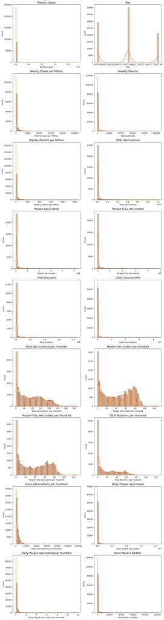

```python
cols_per_row = 2
num_cols = len([col for col in train_set.drop(["Location", "Id"], axis=1).columns] )
rows = (num_cols + cols_per_row - 1) // cols_per_row  #calculation of required number of rows

fig, axes = plt.subplots(rows, cols_per_row, figsize=(12, 5 * rows))
axes = axes.flatten()

for i, col in enumerate(train_set.drop(["Location", "Id"], axis=1).columns):
    sns.histplot(ax = axes[i], x = train_set[col], bins=50, kde=True,  color='chocolate')
    axes[i].set_title(f'{col}', fontsize=14)

#Hide unnecessary axes when the number of columns is odd.
for j in range(num_cols, len(axes)):
    axes[j].set_visible(False)

plt.tight_layout()
plt.show()
```

**The columns have an asymmetric distribution (i.e., many outliers), which can affect the training phase.**

#### DEFINITION OF PREPROCESSING FUNCTIONS

```python
from sklearn.feature_selection import SelectKBest, f_regression
from sklearn.preprocessing import OrdinalEncoder
import numpy as np
from sklearn.preprocessing import RobustScaler
from sklearn.metrics import mean_absolute_error, mean_squared_error, r2_score
from sklearn.model_selection import learning_curve
from math import sqrt


class Preprocessing:

    def __init__(self, df):
        self.df = df

    #Definition of Encoder Function
    def encoding(self) :
        ord_encoder = OrdinalEncoder()
        for col in self.df.select_dtypes('object'):
            self.df[col] = ord_encoder.fit_transform(self.df[[col]])



    #Definition of Imputation
    def imputation(self):
        self.df = self.df.dropna(axis=0).reset_index(drop=True)
        #print(self.df.head(10))


    #Definition of Logarithme
    #The logarithm reduces the asymmetries and stabilizes the variance.
    def logarithme(self):
        for col in list(self.df.columns):
            #if self.df[col].skew() >= 1:
            self.df.loc[:, col] =  np.log1p(self.df[col]) # = np.log(df[col]+1)




    #Definition of feature_engineering
    def feature_engineering(self):

        self.df = self.df.copy()

        self.df['Change in Weekly Cases'] = self.df['Weekly Cases'] - self.df['Weekly Cases'].shift(1)
        self.df['Change in Weekly Deaths'] = self.df['Weekly Deaths'] - self.df['Weekly Deaths'].shift(1)

        # Fill the first two rows of both columns with the value 0.
        self.df['Change in Weekly Cases'].fillna(0, inplace=True)
        self.df['Change in Weekly Deaths'].fillna(0, inplace=True)



    #Definition of RobustScaler
    def robust_scaler(self, df, target):

        df_r_scaler = RobustScaler()
        target_r_scaler = RobustScaler()

        df_scaled =  df_r_scaler.fit_transform(df)
        target_scaled = target_r_scaler.fit_transform(target.to_numpy().reshape(-1, 1)) #Because RobustScaler only accepts a 2D array, and a Pandas Series does not have a reshape method.

        df_scaled = pd.DataFrame(df_scaled, columns=df.columns) #Convert it into a DataFrame with the same columns because RobustScaler returns a NumPy array.
        target_scaled = pd.DataFrame(target_scaled, columns=[target.name])

        return df_scaled, target_scaled, target_r_scaler




    #Feature Selection
    #important : score_func=f_regression is for a continuous numerical target variable.
    def feature_selector(self, df, target, k):
        target1 = target.to_numpy().ravel() #because the selector need a 1D array
        selector = SelectKBest(score_func=f_regression, k=k)
        selector.fit_transform(df, target1)
        selected_features = df.columns[selector.get_support()]

        return df[list(selected_features)]


    # Definition of Preprocessing Function
    def process(self):
        self.encoding()
        self.imputation()
        self.logarithme()
        self.feature_engineering()

        X = self.df.drop("Next Week's Deaths", axis=1)
        y = self.df["Next Week's Deaths"]

        X, y, val_r_scaler = self.robust_scaler(X, y)

        #X = self.feature_selector(X, y, 20)

        return X, y, val_r_scaler



    #evaluation function
    def evaluation(self, model, X_train, y_train, X_val, y_val, val_r_scaler):

        y_train = y_train.to_numpy().ravel()


        #Learning_curve and cross-validation
        N, train_score, val_score = learning_curve( model, X_train, y_train,
                                                   cv = 5, scoring='r2', train_sizes=np.linspace(0.1, 1, 10))

        #training of Model
        model.fit(X_train, y_train)
        y_pred = model.predict(X_val)

        # print(y_pred.shape)
        # print(y_val.shape)

        # print(y_pred)
        # print(y_val)

        # Calculation of the metrics, applying the inverse of the logarithm and RobustScaler beforehand to return to the original data.
        y_pred = np.expm1(val_r_scaler.inverse_transform(y_pred.reshape(-1,1)))  # RobustScaler expect a 2D array, y_pred is 1D
        y_val = np.expm1(val_r_scaler.inverse_transform(y_val.to_numpy())) # to_numpy, because y_val is a pandas dataframe

        # print(y_pred)
        # print(y_val)

        mae = mean_absolute_error(y_pred, y_val)
        mse = mean_squared_error(y_pred, y_val)
        rmse = sqrt(mse)
        r2s = r2_score(y_pred, y_val)

        #creation of a Dataframes for  Metrics
        RegMetriken = pd.DataFrame(
            {
                "EVALUATION METRICS": ["Mean Absolute Erroe", "Mean Squared Error", "R2 Score", "Root Mean Squared Error"],
                "SCORES": [mae, mse, r2s, rmse]
            }
        )

        print(f"\n\nEvaluation results of the model\n\n {RegMetriken}\n\n")



        plt.figure(figsize=(14,7))

        plt.subplot(1,2,1)
        plt.plot(N, train_score.mean(axis=1), label='Train Score with cv=5')
        plt.plot(N, val_score.mean(axis=1), label='Validation Score with cv=5')
        plt.legend()

        plt.subplot(1,2,2)
        plt.scatter(y_val, y_pred)
        plt.xlabel("y Validation")
        plt.ylabel("y Predicted")

        plt.tight_layout()
        plt.show()

        #comparison of actual values and predicted ones
        comparison = pd.DataFrame({
        "Actual values(y_val)" : y_val.ravel() if len(y_val.shape) > 1 else y_val, #ravel, bcause pd.Dataframe needs a 1D array, Flatten with ravel()
        "predicted values(y_pred)" : y_pred.ravel() if len(y_pred.shape) > 1 else y_pred
    })
        comparison['Absolute Error'] = abs(comparison["Actual values(y_val)"] - comparison["predicted values(y_pred)"])

        print(f"Comparison of the predicted values with the actual values\n\n{comparison.head(10)}")


        print("\n****************************************************************************************************************************************")
```

```python
#call of preprocessing function
train_preprocessing = Preprocessing(train_set)
X_train, y_train, _ = train_preprocessing.process()

val_preprocessing = Preprocessing(val_set)
X_val, y_val, val_r_scaler = val_preprocessing.process()
```

```python
X_train.head()
```

|  | Id | Location | Weekly Cases | Year | Weekly Cases per Million | Weekly Deaths | Weekly Deaths per Million | Total Vaccinations | People Vaccinated | People Fully Vaccinated | Total Boosters | Daily Vaccinations | Total Vaccinations per Hundred | People Vaccinated per Hundred | People Fully Vaccinated per Hundred | Total Boosters per Hundred | Daily Vaccinations per Hundred | Daily People Vaccinated | Daily People Vaccinated per Hundred | Change in Weekly Cases | Change in Weekly Deaths |
| --- | --- | --- | --- | --- | --- | --- | --- | --- | --- | --- | --- | --- | --- | --- | --- | --- | --- | --- | --- | --- | --- |
| 0 | -0.585821 | -0.128480 | -0.037661 | 0.0 | 0.623875 | -0.220794 | 0.235415 | -0.368344 | -0.467034 | -0.372089 | 0.102753 | -0.655627 | 0.577877 | 0.395524 | 0.407971 | 0.506547 | -0.599942 | -0.648269 | -0.275791 | -0.000681 | 0.000000 |
| 1 | -0.524440 | -0.613165 | -0.916861 | 0.0 | -1.477418 | -0.787966 | -0.964828 | 0.031686 | -0.000489 | 0.053349 | 0.240047 | -0.271063 | 0.460992 | 0.476912 | 0.377903 | 0.367340 | -0.447614 | -0.436750 | -0.302928 | -0.664669 | -0.410260 |
| 2 | 0.239260 | 0.288518 | -0.640348 | -1.0 | -1.362314 | -0.502756 | -0.910295 | -0.703450 | -0.538985 | -1.000148 | -2.243335 | 0.062476 | -3.480501 | -4.032284 | -4.696751 | -0.685921 | -0.199723 | 0.366111 | 0.772656 | 0.208147 | 0.206305 |
| 3 | 0.190797 | 0.612938 | 0.884800 | -1.0 | -0.295497 | 1.240838 | 0.269707 | -0.382701 | -0.899847 | -4.293622 | -2.001856 | 0.513833 | -6.047904 | -8.091639 | -5.974225 | -0.685921 | -1.592151 | 0.357599 | -0.366561 | 1.151139 | 1.261218 |
| 4 | -0.227316 | -0.148290 | -0.087805 | 0.0 | -0.657244 | 0.165473 | -0.299145 | 0.520060 | 0.510786 | 0.531950 | 0.491690 | 0.057072 | 0.260589 | 0.176432 | 0.106625 | 0.323765 | -0.634931 | 0.085567 | -0.212785 | -0.735210 | -0.777858 |

```python
y_train.head()
```

|  | Next Week's Deaths |
| --- | --- |
| 0 | -0.182779 |
| 1 | -0.570141 |
| 2 | -0.440645 |
| 3 | 1.253895 |
| 4 | 0.152041 |

```python
X_val.head()
```

|  | Id | Location | Weekly Cases | Year | Weekly Cases per Million | Weekly Deaths | Weekly Deaths per Million | Total Vaccinations | People Vaccinated | People Fully Vaccinated | Total Boosters | Daily Vaccinations | Total Vaccinations per Hundred | People Vaccinated per Hundred | People Fully Vaccinated per Hundred | Total Boosters per Hundred | Daily Vaccinations per Hundred | Daily People Vaccinated | Daily People Vaccinated per Hundred | Change in Weekly Cases | Change in Weekly Deaths |
| --- | --- | --- | --- | --- | --- | --- | --- | --- | --- | --- | --- | --- | --- | --- | --- | --- | --- | --- | --- | --- | --- |
| 0 | 0.596986 | -0.492328 | 0.979649 | -1.0 | 0.319766 | 1.285056 | 0.963111 | -0.540310 | -0.329897 | -1.072018 | -1.854039 | 0.428265 | -5.981057 | -7.432045 | -6.338454 | -0.695839 | -1.041286 | 0.743761 | 0.027133 | 0.000035 | 0.000000 |
| 1 | -1.242596 | 0.288518 | -0.530639 | 0.0 | -0.356750 | -0.179400 | 0.240976 | -0.339854 | -0.435509 | -0.299885 | 0.113072 | -1.011875 | 0.571539 | 0.358889 | 0.312561 | 0.488151 | -1.539455 | -1.026895 | -0.378852 | -1.131724 | -1.100185 |
| 2 | -1.206062 | 0.294906 | -0.767186 | -1.0 | -1.638385 | -0.624341 | -0.991584 | -0.828157 | -0.664786 | -1.086853 | -2.191878 | -0.015337 | -4.138867 | -4.920713 | -5.466222 | -0.695839 | -0.396131 | 0.330038 | 0.647543 | -0.177225 | -0.334265 |
| 3 | -0.462574 | 0.490516 | 0.811217 | -1.0 | 0.242377 | 1.253682 | 1.174724 | 0.325344 | 0.466014 | 0.330110 | -1.498679 | 0.775537 | -2.682443 | -3.266519 | -3.340602 | -0.695839 | 0.141841 | 0.908834 | 1.077399 | 1.182838 | 1.410880 |
| 4 | -0.180188 | 0.458711 | -0.047910 | 0.0 | 0.508739 | -0.477714 | -0.358206 | -0.270373 | -0.384608 | -0.233330 | 0.164356 | -0.609075 | 0.843306 | 0.629648 | 0.606726 | 0.572601 | -0.561552 | -0.821929 | -0.350610 | -0.643766 | -1.300725 |

```python
y_val.head()
```

|  | Next Week's Deaths |
| --- | --- |
| 0 | 1.287218 |
| 1 | -0.130583 |
| 2 | -0.455893 |
| 3 | 1.223960 |
| 4 | -0.706320 |

##### Variables distribution display after Preprocessing

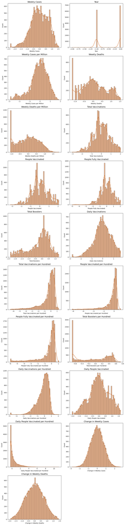

```python
cols_per_row = 2

# check of the presence of columns befor we delete them
columns_to_drop = ["Location", "Id"] if all(col in X_train.columns for col in ["Location", "Id"]) else []
filtered_X_train = X_train.drop(columns_to_drop, axis=1)

num_cols = len(filtered_X_train.columns)
rows = (num_cols + cols_per_row - 1) // cols_per_row  #calculation of number of required rows

fig, axes = plt.subplots(rows, cols_per_row, figsize=(12, 5 * rows))
axes = axes.flatten()

for i, col in enumerate(filtered_X_train.columns):
    sns.histplot(ax = axes[i], x = X_train[col], bins=50, kde=True,  color='chocolate')
    axes[i].set_title(f'{col}', fontsize=14)


#Hide unnecessary axes when the number of columns is odd.
for j in range(num_cols, len(axes)):
    axes[j].set_visible(False)

plt.tight_layout()
plt.show()
```

**Now the assymetric distribution of variables seems to be reduced.**

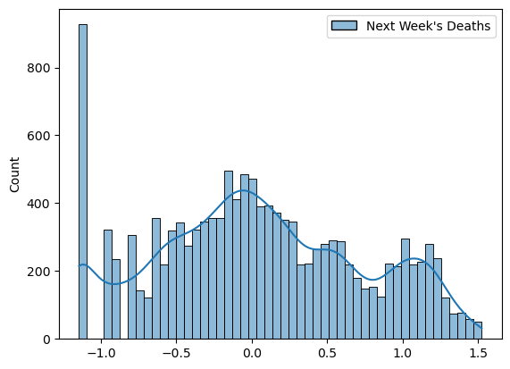

```python
#Distribution of Target after preprocessing
sns.histplot(y_train, bins=50, kde=True)
#plt.title(f'{list(y_train.columns)[0]}', fontsize=14)
```

#### Evaluation and Diagnosis

##### First Model

```
Evaluation results of the model

         EVALUATION METRICS        SCORES
0      Mean Absolute Erroe  4.151796e+02
1       Mean Squared Error  1.768300e+06
2                 R2 Score  9.855552e-01
3  Root Mean Squared Error  1.329775e+03
```

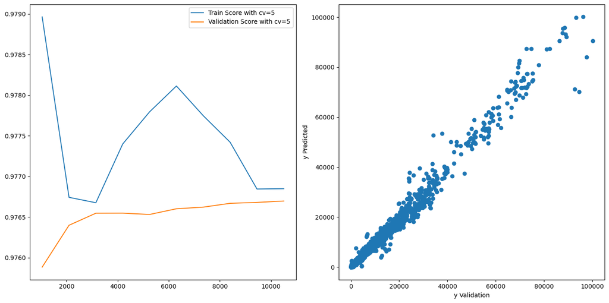

```
Comparison of the predicted values with the actual values

   Actual values(y_val)  predicted values(y_pred)  Absolute Error
0               37695.0              35331.979293     2363.020707
1                  74.0                 35.550778       38.449222
2                  17.0                  8.915562        8.084438
3               28560.0              25497.210696     3062.789304
4                   5.0                 17.077282       12.077282
5                   0.0                 -0.150388        0.150388
6                   5.0                  3.613460        1.386540
7                   3.0                  3.277905        0.277905
8                8548.0               9534.149272      986.149272
9                  46.0                 42.145341        3.854659
```

```python
from sklearn.linear_model import LinearRegression

model = LinearRegression()
val_preprocessing.evaluation(model, X_train, y_train, X_val, y_val, val_r_scaler)
```

# III. MODELLING AND TRAINING

### Evaluation and Optimization class

```python
from sklearn.model_selection import GridSearchCV
import time
from tqdm import tqdm

class Training(Preprocessing):

    def __init__(self, df):
        super().__init__(df)

    #Redefinition of Method process()
    def process(self):
        self.encoding()
        self.imputation()
        self.logarithme()
        self.feature_engineering()

        X = self.df.drop("Next Week's Deaths", axis=1)
        y = self.df["Next Week's Deaths"]

        X, y, val_r_scaler = self.robust_scaler(X, y)

        return X, y, val_r_scaler



    #evaluation function
    def assess(self, model, X_train, y_train, X_val, y_val, val_r_scaler):

        y_train = y_train.to_numpy().ravel()

        #training of Model
        model.fit(X_train, y_train)
        y_pred = model.predict(X_val)

        # Calculation of the metrics, applying the inverse of the logarithm and RobustScaler beforehand to return to the original data.
        y_pred = np.expm1(val_r_scaler.inverse_transform(y_pred.reshape(-1,1)))
        y_val = np.expm1(val_r_scaler.inverse_transform(y_val.to_numpy()))

        mae = mean_absolute_error(y_pred, y_val)
        mse = mean_squared_error(y_pred, y_val)
        rmse = sqrt(mse)
        r2s = r2_score(y_pred, y_val)

        #creation of a Dataframes for Metrics
        RegMetriken = pd.DataFrame(
            {
                "EVALUATION METRICS": ["Mean Absolute Erroe", "Mean Squared Error", "R2 Score", "Root Mean Squared Error"],
                "SCORES": [mae, mse, r2s, rmse]
            }
        )

        print(f"\n\nEEvaluation results of the model\n\n {RegMetriken}\n\n")

        plt.figure()

        plt.scatter(y_val, y_pred)
        plt.xlabel("y Validation")
        plt.ylabel("y Predicted")

        plt.show()

       #comparison of actual values and predicted ones
        comparison = pd.DataFrame({
        "Actual values(y_val)" : y_val.ravel() if len(y_val.shape) > 1 else y_val, #ravel, bcause pd.Dataframe needs a 1D array, Flatten with ravel()
        "predicted values(y_pred)" : y_pred.ravel() if len(y_pred.shape) > 1 else y_pred
    })
        comparison['Absolute Error'] = abs(comparison["Actual values(y_val)"] - comparison["predicted values(y_pred)"])

        print(f"Comparison of the predicted values with the actual values\n\n{comparison.head(10)}")



    def optimize(self, model_dict, param_dict, X_train, y_train, X_val, y_val, val_r_scaler):
            start_time = time.time()
            print(f"Optimisation started at {time.strftime('%H:%M:%S', time.localtime(start_time))}")

            for name, model in tqdm(model_dict.items(), desc="Optimisation in process", unit="model"):
                print(f"************************* {name.upper()} ****************************")
                grid = GridSearchCV(model, param_dict[name], cv = 5, scoring='r2')
                self.assess(grid, X_train, y_train, X_val, y_val, val_r_scaler)
                print(f"BEST ESTIMATOR : {grid.best_estimator_.get_params()}")
                print(f"BEST PARAMETERS : {grid.best_params_}")
                print(f"BEST SCORE : {grid.best_score_}")

                print("\n****************************************************************************************************************************************")

            # display of the execution time
            end_time = time.time()
            elapsed_time = end_time - start_time
            estimated_end_time = start_time + elapsed_time  # Heure estimée de fin
            print(f"Optimisation finished at {time.strftime('%H:%M:%S', time.localtime(estimated_end_time))}")
            print(f"Total time : {elapsed_time / 60:.2f} minutes")
```

### Training of different models

```python
from sklearn.neighbors import KNeighborsRegressor
from sklearn.tree import DecisionTreeRegressor
from sklearn.ensemble import RandomForestRegressor
from sklearn.linear_model import LinearRegression
from sklearn.svm import SVR

KNN = KNeighborsRegressor()
RandomForest = RandomForestRegressor(random_state=0)
SVR = SVR()
DecisionTree = DecisionTreeRegressor(random_state=0)
LRegressor = LinearRegression()
```

```python
model_dict = {
    'KNN': KNN,
    'SVR': SVR,
    'DecisionTree': DecisionTree,
    'LRegressor': LRegressor,
    'RandomForest': RandomForest
}
```

```python
train_training = Training(train_set)
X_train, y_train, _ = train_training.process()

val_Training = Training(val_set)
X_val, y_val, val_r_scaler = val_Training.process()
```

```python
X_val.head()
```

|  | Id | Location | Weekly Cases | Year | Weekly Cases per Million | Weekly Deaths | Weekly Deaths per Million | Total Vaccinations | People Vaccinated | People Fully Vaccinated | Total Boosters | Daily Vaccinations | Total Vaccinations per Hundred | People Vaccinated per Hundred | People Fully Vaccinated per Hundred | Total Boosters per Hundred | Daily Vaccinations per Hundred | Daily People Vaccinated | Daily People Vaccinated per Hundred | Change in Weekly Cases | Change in Weekly Deaths |
| --- | --- | --- | --- | --- | --- | --- | --- | --- | --- | --- | --- | --- | --- | --- | --- | --- | --- | --- | --- | --- | --- |
| 0 | 0.596986 | -0.492328 | 0.979649 | -1.0 | 0.319766 | 1.285056 | 0.963111 | -0.540310 | -0.329897 | -1.072018 | -1.854039 | 0.428265 | -5.981057 | -7.432045 | -6.338454 | -0.695839 | -1.041286 | 0.743761 | 0.027133 | 0.000035 | 0.000000 |
| 1 | -1.242596 | 0.288518 | -0.530639 | 0.0 | -0.356750 | -0.179400 | 0.240976 | -0.339854 | -0.435509 | -0.299885 | 0.113072 | -1.011875 | 0.571539 | 0.358889 | 0.312561 | 0.488151 | -1.539455 | -1.026895 | -0.378852 | -1.131724 | -1.100185 |
| 2 | -1.206062 | 0.294906 | -0.767186 | -1.0 | -1.638385 | -0.624341 | -0.991584 | -0.828157 | -0.664786 | -1.086853 | -2.191878 | -0.015337 | -4.138867 | -4.920713 | -5.466222 | -0.695839 | -0.396131 | 0.330038 | 0.647543 | -0.177225 | -0.334265 |
| 3 | -0.462574 | 0.490516 | 0.811217 | -1.0 | 0.242377 | 1.253682 | 1.174724 | 0.325344 | 0.466014 | 0.330110 | -1.498679 | 0.775537 | -2.682443 | -3.266519 | -3.340602 | -0.695839 | 0.141841 | 0.908834 | 1.077399 | 1.182838 | 1.410880 |
| 4 | -0.180188 | 0.458711 | -0.047910 | 0.0 | 0.508739 | -0.477714 | -0.358206 | -0.270373 | -0.384608 | -0.233330 | 0.164356 | -0.609075 | 0.843306 | 0.629648 | 0.606726 | 0.572601 | -0.561552 | -0.821929 | -0.350610 | -0.643766 | -1.300725 |

```python
y_val.head()
```

|  | Next Week's Deaths |
| --- | --- |
| 0 | 1.287218 |
| 1 | -0.130583 |
| 2 | -0.455893 |
| 3 | 1.223960 |
| 4 | -0.706320 |

### Evaluation of the models

```
Training started at 00:34:03
```

```
************************* KNN ****************************


Evaluation results of the model

         EVALUATION METRICS        SCORES
0      Mean Absolute Erroe  5.439604e+02
1       Mean Squared Error  3.409667e+06
2                 R2 Score  9.732547e-01
3  Root Mean Squared Error  1.846528e+03
```

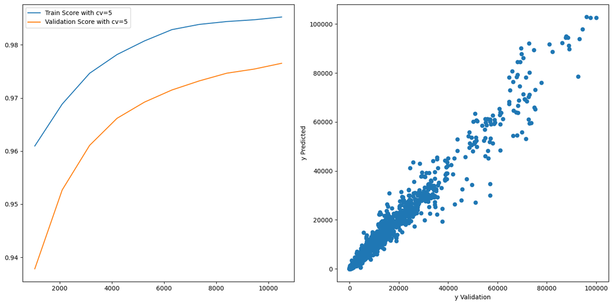

```
Comparison of the predicted values with the actual values

   Actual values(y_val)  predicted values(y_pred)  Absolute Error
0               37695.0              19445.207310    18249.792690
1                  74.0                 42.697860       31.302140
2                  17.0                 11.593919        5.406081
3               28560.0              30775.108425     2215.108425
4                   5.0                  8.819630        3.819630
5                   0.0                 -0.124869        0.124869
6                   5.0                  4.798278        0.201722
7                   3.0                  4.880070        1.880070
8                8548.0               9679.340430     1131.340430
9                  46.0                 94.154328       48.154328

************************* SVR ****************************


Evaluation results of the model

         EVALUATION METRICS        SCORES
0      Mean Absolute Erroe  7.829830e+02
1       Mean Squared Error  8.060651e+06
2                 R2 Score  9.223819e-01
3  Root Mean Squared Error  2.839129e+03
```

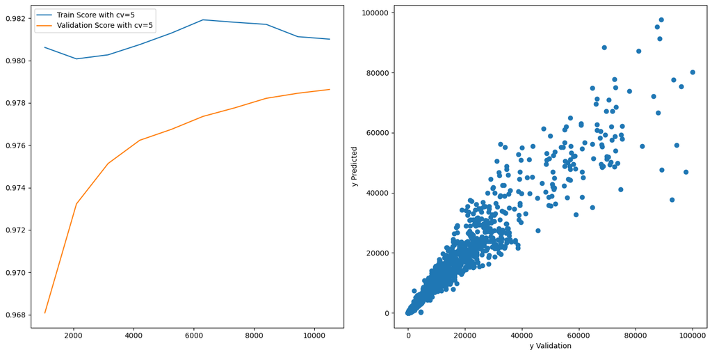

```
Comparison of the predicted values with the actual values

   Actual values(y_val)  predicted values(y_pred)  Absolute Error
0               37695.0              23656.488879    14038.511121
1                  74.0                 37.888822       36.111178
2                  17.0                  8.969101        8.030899
3               28560.0              34637.043302     6077.043302
4                   5.0                 15.811865       10.811865
5                   0.0                 -0.107570        0.107570
6                   5.0                  4.459964        0.540036
7                   3.0                  4.209750        1.209750
8                8548.0               8992.794064      444.794064
9                  46.0                 66.684992       20.684992

************************* DECISIONTREE ****************************


Evaluation results of the model

         EVALUATION METRICS        SCORES
0      Mean Absolute Erroe  3.521795e+02
1       Mean Squared Error  1.526965e+06
2                 R2 Score  9.886686e-01
3  Root Mean Squared Error  1.235704e+03
```

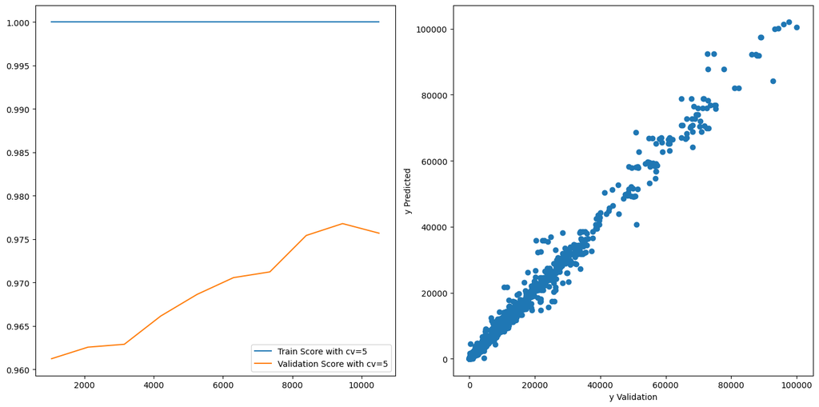

```
Comparison of the predicted values with the actual values

   Actual values(y_val)  predicted values(y_pred)  Absolute Error
0               37695.0              38450.765753      755.765753
1                  74.0                 13.602752       60.397248
2                  17.0                 14.529680        2.470320
3               28560.0              31941.457392     3381.457392
4                   5.0                 10.827472        5.827472
5                   0.0                 -0.124869        0.124869
6                   5.0                  0.768737        4.231263
7                   3.0                  2.574817        0.425183
8                8548.0               9589.987510     1041.987510
9                  46.0                 31.324574       14.675426

************************* LREGRESSOR ****************************


Evaluation results of the model

         EVALUATION METRICS        SCORES
0      Mean Absolute Erroe  4.151796e+02
1       Mean Squared Error  1.768300e+06
2                 R2 Score  9.855552e-01
3  Root Mean Squared Error  1.329775e+03
```

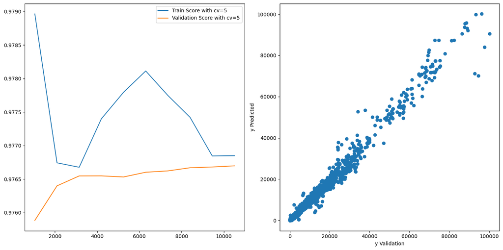

```
Comparison of the predicted values with the actual values

   Actual values(y_val)  predicted values(y_pred)  Absolute Error
0               37695.0              35331.979293     2363.020707
1                  74.0                 35.550778       38.449222
2                  17.0                  8.915562        8.084438
3               28560.0              25497.210696     3062.789304
4                   5.0                 17.077282       12.077282
5                   0.0                 -0.150388        0.150388
6                   5.0                  3.613460        1.386540
7                   3.0                  3.277905        0.277905
8                8548.0               9534.149272      986.149272
9                  46.0                 42.145341        3.854659

************************* RANDOMFOREST ****************************


Evaluation results of the model

         EVALUATION METRICS         SCORES
0      Mean Absolute Erroe     284.029814
1       Mean Squared Error  891292.563257
2                 R2 Score       0.993330
3  Root Mean Squared Error     944.082922
```

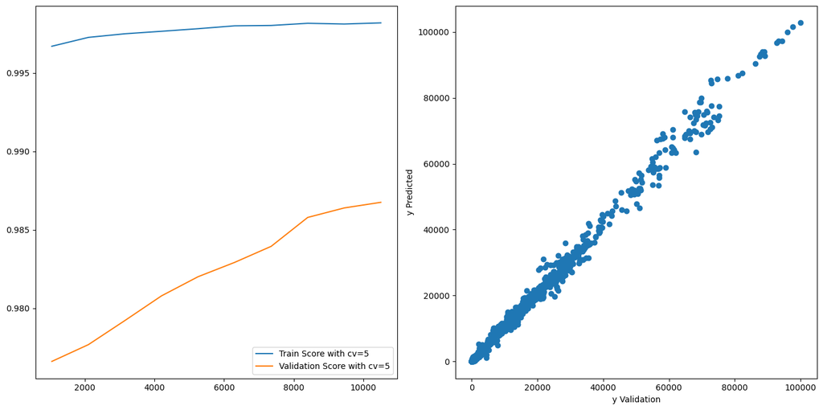

```
Comparison of the predicted values with the actual values

   Actual values(y_val)  predicted values(y_pred)  Absolute Error
0               37695.0              37933.986385      238.986385
1                  74.0                 47.958062       26.041938
2                  17.0                 10.593458        6.406542
3               28560.0              31415.986511     2855.986511
4                   5.0                 13.096239        8.096239
5                   0.0                 -0.074194        0.074194
6                   5.0                  5.170897        0.170897
7                   3.0                  2.511988        0.488012
8                8548.0               9588.854733     1040.854733
9                  46.0                 40.165745        5.834255

Training finished at 00:42:13
Total time : 8.18 minutes
```

```python
import time
from tqdm import tqdm

start_time = time.time()
print(f"Training started at {time.strftime('%H:%M:%S', time.localtime(start_time))}")

for name, model in tqdm(model_dict.items(), desc="Training in process", unit="model"):
    print(f"************************* {name.upper()} ****************************")
    train_training.evaluation(model, X_train, y_train, X_val, y_val, val_r_scaler)

# Anzeige der Ausführungszeit
end_time = time.time()
elapsed_time = end_time - start_time
estimated_end_time = start_time + elapsed_time  # Heure estimée de fin
print(f"Training finished at {time.strftime('%H:%M:%S', time.localtime(estimated_end_time))}")
print(f"Total time : {elapsed_time / 60:.2f} minutes")
```

#### Optimization

```python
for name, model in model_dict.items():
    print(f"******************{name.upper()}*******************")
    print(model.get_params())
```

```
******************KNN*******************
{'algorithm': 'auto', 'leaf_size': 30, 'metric': 'minkowski', 'metric_params': None, 'n_jobs': None, 'n_neighbors': 5, 'p': 2, 'weights': 'uniform'}
******************SVR*******************
{'C': 1.0, 'cache_size': 200, 'coef0': 0.0, 'degree': 3, 'epsilon': 0.1, 'gamma': 'scale', 'kernel': 'rbf', 'max_iter': -1, 'shrinking': True, 'tol': 0.001, 'verbose': False}
******************DECISIONTREE*******************
{'ccp_alpha': 0.0, 'criterion': 'squared_error', 'max_depth': None, 'max_features': None, 'max_leaf_nodes': None, 'min_impurity_decrease': 0.0, 'min_samples_leaf': 1, 'min_samples_split': 2, 'min_weight_fraction_leaf': 0.0, 'random_state': 0, 'splitter': 'best'}
******************LREGRESSOR*******************
{'copy_X': True, 'fit_intercept': True, 'n_jobs': None, 'positive': False}
******************RANDOMFOREST*******************
{'bootstrap': True, 'ccp_alpha': 0.0, 'criterion': 'squared_error', 'max_depth': None, 'max_features': 1.0, 'max_leaf_nodes': None, 'max_samples': None, 'min_impurity_decrease': 0.0, 'min_samples_leaf': 1, 'min_samples_split': 2, 'min_weight_fraction_leaf': 0.0, 'n_estimators': 100, 'n_jobs': None, …
```

```python
knn_hyper_params = {
    'n_neighbors': [3,5, 7, 10],
    'weights': ['uniform', 'distance'],
    'p': [1, 2],
}

svr_hyper_params = {
    'C': [0.1, 1.0],

}

tree_hyper_params = {
    'max_depth': [5, 10, 15, 20, None],

}
lregressor_hyper_params = {
    'positive': [False, True]
}

randomforest_hyper_params = {
    'max_depth': [5, 10, None],
    'min_samples_leaf': [1, 2],
    'min_samples_split': [2, 3],
    'n_estimators': [100]

}
```

```python
param_dict = {
    'KNN': knn_hyper_params,
    'SVR': svr_hyper_params,
    'DecisionTree': tree_hyper_params,
    'LRegressor': lregressor_hyper_params,
    'RandomForest': randomforest_hyper_params
}
```

```
Optimisation started at 00:42:13
```

```
************************* KNN ****************************


EEvaluation results of the model

         EVALUATION METRICS        SCORES
0      Mean Absolute Erroe  3.235717e+02
1       Mean Squared Error  1.202035e+06
2                 R2 Score  9.908134e-01
3  Root Mean Squared Error  1.096373e+03
```

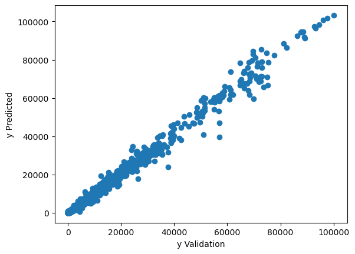

```
Comparison of the predicted values with the actual values

   Actual values(y_val)  predicted values(y_pred)  Absolute Error
0               37695.0              24002.241892    13692.758108
1                  74.0                 50.192312       23.807688
2                  17.0                 11.505044        5.494956
3               28560.0              31444.161664     2884.161664
4                   5.0                  8.471164        3.471164
5                   0.0                 -0.124869        0.124869
6                   5.0                  4.398123        0.601877
7                   3.0                  4.481572        1.481572
8                8548.0               8394.523774      153.476226
9                  46.0                 59.712906       13.712906
BEST ESTIMATOR : {'algorithm': 'auto', 'leaf_size': 30, 'metric': 'minkowski', 'metric_params': None, 'n_jobs': None, 'n_neighbors': 5, 'p': 1, 'weights': 'distance'}
BEST PARAMETERS : {'n_neighbors': 5, 'p': 1, 'weights': 'distance'}
BEST SCORE : 0.9857486645527

************************* SVR ****************************


EEvaluation results of the model

         EVALUATION METRICS        SCORES
0      Mean Absolute Erroe  7.829830e+02
1       Mean Squared Error  8.060651e+06
2                 R2 Score  9.223819e-01
3  Root Mean Squared Error  2.839129e+03
```

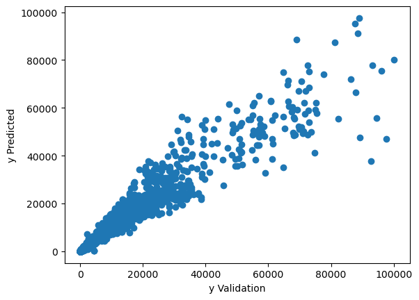

```
Comparison of the predicted values with the actual values

   Actual values(y_val)  predicted values(y_pred)  Absolute Error
0               37695.0              23656.488879    14038.511121
1                  74.0                 37.888822       36.111178
2                  17.0                  8.969101        8.030899
3               28560.0              34637.043302     6077.043302
4                   5.0                 15.811865       10.811865
5                   0.0                 -0.107570        0.107570
6                   5.0                  4.459964        0.540036
7                   3.0                  4.209750        1.209750
8                8548.0               8992.794064      444.794064
9                  46.0                 66.684992       20.684992
BEST ESTIMATOR : {'C': 1.0, 'cache_size': 200, 'coef0': 0.0, 'degree': 3, 'epsilon': 0.1, 'gamma': 'scale', 'kernel': 'rbf', 'max_iter': -1, 'shrinking': True, 'tol': 0.001, 'verbose': False}
BEST PARAMETERS : {'C': 1.0}
BEST SCORE : 0.9786340994259801

************************* DECISIONTREE ****************************


EEvaluation results of the model

         EVALUATION METRICS        SCORES
0      Mean Absolute Erroe  3.759650e+02
1       Mean Squared Error  1.385560e+06
2                 R2 Score  9.895087e-01
3  Root Mean Squared Error  1.177098e+03
```

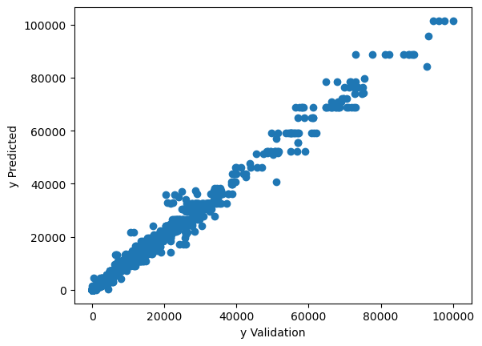

```
Comparison of the predicted values with the actual values

   Actual values(y_val)  predicted values(y_pred)  Absolute Error
0               37695.0              36137.545756     1557.454244
1                  74.0                 38.431932       35.568068
2                  17.0                  4.395264       12.604736
3               28560.0              32619.217244     4059.217244
4                   5.0                 14.474709        9.474709
5                   0.0                 -0.061780        0.061780
6                   5.0                  6.116067        1.116067
7                   3.0                  2.574817        0.425183
8                8548.0               9150.612582      602.612582
9                  46.0                 28.012211       17.987789
BEST ESTIMATOR : {'ccp_alpha': 0.0, 'criterion': 'squared_error', 'max_depth': 10, 'max_features': None, 'max_leaf_nodes': None, 'min_impurity_decrease': 0.0, 'min_samples_leaf': 1, 'min_samples_split': 2, 'min_weight_fraction_leaf': 0.0, 'random_state': 0, 'splitter': 'best'}
BEST PARAMETERS : {'max_depth': 10}
BEST SCORE : 0.9776904900227367

************************* LREGRESSOR ****************************


EEvaluation results of the model

         EVALUATION METRICS        SCORES
0      Mean Absolute Erroe  4.151796e+02
1       Mean Squared Error  1.768300e+06
2                 R2 Score  9.855552e-01
3  Root Mean Squared Error  1.329775e+03
```

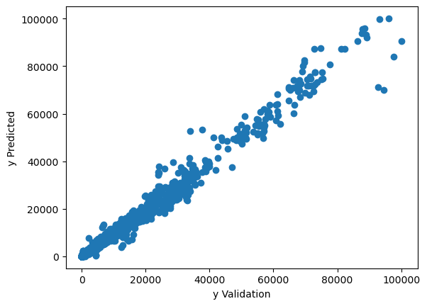

```
Comparison of the predicted values with the actual values

   Actual values(y_val)  predicted values(y_pred)  Absolute Error
0               37695.0              35331.979293     2363.020707
1                  74.0                 35.550778       38.449222
2                  17.0                  8.915562        8.084438
3               28560.0              25497.210696     3062.789304
4                   5.0                 17.077282       12.077282
5                   0.0                 -0.150388        0.150388
6                   5.0                  3.613460        1.386540
7                   3.0                  3.277905        0.277905
8                8548.0               9534.149272      986.149272
9                  46.0                 42.145341        3.854659
BEST ESTIMATOR : {'copy_X': True, 'fit_intercept': True, 'n_jobs': None, 'positive': False}
BEST PARAMETERS : {'positive': False}
BEST SCORE : 0.9766969510924867

************************* RANDOMFOREST ****************************


EEvaluation results of the model

         EVALUATION METRICS         SCORES
0      Mean Absolute Erroe     284.029814
1       Mean Squared Error  891292.563257
2                 R2 Score       0.993330
3  Root Mean Squared Error     944.082922
```

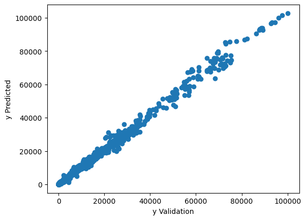

```
Comparison of the predicted values with the actual values

   Actual values(y_val)  predicted values(y_pred)  Absolute Error
0               37695.0              37933.986385      238.986385
1                  74.0                 47.958062       26.041938
2                  17.0                 10.593458        6.406542
3               28560.0              31415.986511     2855.986511
4                   5.0                 13.096239        8.096239
5                   0.0                 -0.074194        0.074194
6                   5.0                  5.170897        0.170897
7                   3.0                  2.511988        0.488012
8                8548.0               9588.854733     1040.854733
9                  46.0                 40.165745        5.834255
BEST ESTIMATOR : {'bootstrap': True, 'ccp_alpha': 0.0, 'criterion': 'squared_error', 'max_depth': None, 'max_features': 1.0, 'max_leaf_nodes': None, 'max_samples': None, 'min_impurity_decrease': 0.0, 'min_samples_leaf': 1, 'min_samples_split': 2, 'min_weight_fraction_leaf': 0.0, 'n_estimators': 100,…
BEST PARAMETERS : {'max_depth': None, 'min_samples_leaf': 1, 'min_samples_split': 2, 'n_estimators': 100}
BEST SCORE : 0.9867420281220853

Optimisation finished at 00:53:20
Total time : 11.11 minutes
```

```python
train_training.optimize(model_dict, param_dict, X_train, y_train, X_val, y_val, val_r_scaler)
```

### Usage of ensemble Learners

#### The Voting

Voting is an ensemble learning technique that combines the predictions of multiple models to obtain a final prediction. In classification, the final class is chosen by majority voting or weighted voting, and in regression, it is the average of the predictions. The base models can already be trained before they are used in the voting system. The voting estimator does not retrain the base models but only learns how to combine their outputs.

[figure not shown]

```python
from sklearn.ensemble import VotingRegressor

#Usage of trained Models for voting method
voting_model = VotingRegressor([(name, model) for name,model in model_dict.items()])
```

```
EEvaluation results of the model

         EVALUATION METRICS        SCORES
0      Mean Absolute Erroe  3.178563e+02
1       Mean Squared Error  1.021972e+06
2                 R2 Score  9.915009e-01
3  Root Mean Squared Error  1.010926e+03
```

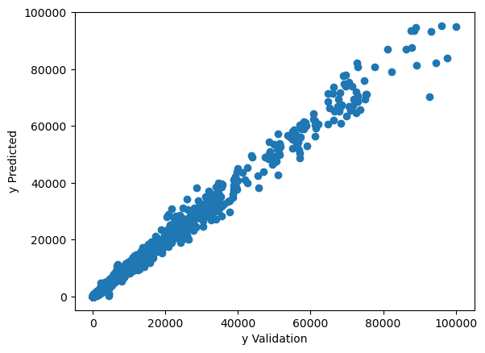

```
Comparison of the predicted values with the actual values

   Actual values(y_val)  predicted values(y_pred)  Absolute Error
0               37695.0              29852.001794     7842.998206
1                  74.0                 32.844500       41.155500
2                  17.0                 10.751734        6.248266
3               28560.0              30700.664524     2140.664524
4                   5.0                 12.783765        7.783765
5                   0.0                 -0.116733        0.116733
6                   5.0                  3.370241        1.629759
7                   3.0                  3.397921        0.397921
8                8548.0               9473.739624      925.739624
9                  46.0                 50.711213        4.711213
```

```python
train_training.assess(voting_model, X_train, y_train, X_val, y_val, val_r_scaler)
```

#### The Bagging

The idea is to create multiple instances of a model (e.g., multiple decision trees) and train each of these instances on a random subset of our dataset. This is done using a sampling technique called **BOOTSTRAPPING**, where random samples are drawn with replacement from the dataset. This means that after each selection, the selected data is put back into the dataset and can be selected again.

In this way, a variety of models is created, each of which differs from the others because they were not all trained on the same data. Nevertheless, they share some common knowledge as they originate from the same original dataset.

Once this ensemble of models is created, their predictions are combined (e.g., by averaging for regression problems or by majority vote for classification problems) to obtain the final prediction.

The most well-known example of an algorithm that uses this method is Random Forest, which uses decision trees as base models and additionally introduces a random selection of features to create even more diversity.

[figure not shown]

```python
from sklearn.ensemble import BaggingRegressor

bagging_model = BaggingRegressor(estimator = RandomForestRegressor(n_estimators=100, random_state=0),
                                 n_estimators = 10, random_state=0)
```

```
EEvaluation results of the model

         EVALUATION METRICS        SCORES
0      Mean Absolute Erroe  3.082179e+02
1       Mean Squared Error  1.022234e+06
2                 R2 Score  9.923474e-01
3  Root Mean Squared Error  1.011056e+03
```

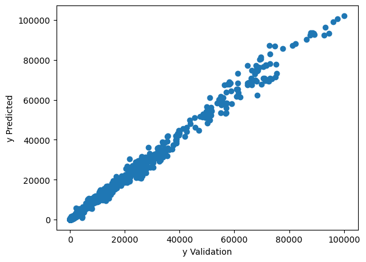

```
Comparison of the predicted values with the actual values

   Actual values(y_val)  predicted values(y_pred)  Absolute Error
0               37695.0              37328.653960      366.346040
1                  74.0                 46.933021       27.066979
2                  17.0                  8.652566        8.347434
3               28560.0              31405.944083     2845.944083
4                   5.0                 13.697607        8.697607
5                   0.0                 -0.024513        0.024513
6                   5.0                  5.294709        0.294709
7                   3.0                  3.060650        0.060650
8                8548.0               9606.377374     1058.377374
9                  46.0                 38.737063        7.262937
```

```python
train_training.assess(bagging_model, X_train, y_train, X_val, y_val, val_r_scaler)
```

#### SAVING THE BEST MODELS ON THE HARD DISK

```python
import joblib

joblib.dump(model_dict['RandomForest'], 'RandomForest.pkl')
joblib.dump(bagging_model, 'bagging_model.pkl')
joblib.dump(voting_model, 'voting_model.pkl')
joblib.dump(model_dict['KNN'], 'KNN_regressor.pkl')
```

```
['KNN_regressor.pkl']
```

# IV. TEST PHASE

```python
class Test(Training):

    def __init__(self, df):
        super().__init__(df)

    #Redefinition of the method assess() (important: the class Test inherits from the class Training, and assess() is a method of the Training class)
    def assess(self, model, X_test, test_df_r_scaler):
        #test
        y_pred = model.predict(X_test)

        #Calculation of the metrics, applying the inverse of the logarithm and RobustScaler beforehand to return to the original data
        y_pred = np.expm1(val_r_scaler.inverse_transform(y_pred.reshape(-1,1)))

        print(y_pred)

        return y_pred






    def test(self, test_model_dict, X_test, test_df_r_scaler):

        list_prediction = []

        for name, model in tqdm(test_model_dict.items(), desc="Test in process", unit="model"):

                print(f"************************* {name.upper()} ****************************")
                list_prediction.append(self.assess(model, X_test, test_df_r_scaler))

                print("\n****************************************************************************************************************************************")
        return list_prediction


    #Redefinition of the method process() (important: the class Test inherits from the class Training, which in turn inherits from the class Preprocessing, and process() is a method of the Preprocessing class)
    def process(self):
        self.encoding()
        self.imputation()

        ids = self.df['Id'] # we need Ids at the End

        self.logarithme()
        self.feature_engineering()

        X = self.df

        X, test_df_r_scaler = self.robust_scaler(X)

        #X = self.feature_selector(X, y, 20)

        return X, test_df_r_scaler, ids


    #Redefinition of the method robust_scaler() (important: robust_scaler is a method of the Preprocessing class)
    def robust_scaler(self, df):

        df_r_scaler = RobustScaler()

        df_scaled =  df_r_scaler.fit_transform(df)
        df_scaled = pd.DataFrame(df_scaled, columns=df.columns) #Convert into a DataFrame with the same columns because R_scaler returns a NumPy array


        return df_scaled, df_r_scaler
```

```python
import pandas as pd

test_df = pd.read_csv("test.csv")
test_df.head()
```

|  | Id | Location | Weekly Cases | Year | Weekly Cases per Million | Weekly Deaths | Weekly Deaths per Million | Total Vaccinations | People Vaccinated | People Fully Vaccinated | Total Boosters | Daily Vaccinations | Total Vaccinations per Hundred | People Vaccinated per Hundred | People Fully Vaccinated per Hundred | Total Boosters per Hundred | Daily Vaccinations per Hundred | Daily People Vaccinated | Daily People Vaccinated per Hundred |
| --- | --- | --- | --- | --- | --- | --- | --- | --- | --- | --- | --- | --- | --- | --- | --- | --- | --- | --- | --- |
| 0 | 719557359 | Monaco | 185.0 | 2021 | 5042.796 | 0.0 | 0.00 | NaN | NaN | NaN | NaN | 158.0 | NaN | NaN | NaN | NaN | 4307.0 | 23.0 | 0.063 |
| 1 | 507527289 | Liechtenstein | 78.0 | 2020 | 1998.002 | 0.0 | 0.00 | NaN | NaN | NaN | NaN | NaN | NaN | NaN | NaN | NaN | NaN | NaN | NaN |
| 2 | 821551528 | Albania | 230.0 | 2022 | 80.569 | 1.0 | 0.35 | NaN | NaN | NaN | NaN | 1462.0 | NaN | NaN | NaN | NaN | 512.0 | 391.0 | 0.014 |
| 3 | 696602016 | Niger | 14.0 | 2022 | 0.554 | 1.0 | 0.04 | NaN | NaN | NaN | NaN | 72018.0 | NaN | NaN | NaN | NaN | 2852.0 | 60442.0 | 0.239 |
| 4 | 680387432 | French Polynesia | 1033.0 | 2022 | 3397.669 | 0.0 | 0.00 | 366984.0 | 186177.0 | 180807.0 | NaN | 22.0 | 120.71 | 61.24 | 59.47 | NaN | 72.0 | 22.0 | 0.007 |

```python
test_phase = Test(test_df)
X_test, test_df_r_scaler, ids  = test_phase.process()
```

```python
X_test
```

|  | Id | Location | Weekly Cases | Year | Weekly Cases per Million | Weekly Deaths | Weekly Deaths per Million | Total Vaccinations | People Vaccinated | People Fully Vaccinated | Total Boosters | Daily Vaccinations | Total Vaccinations per Hundred | People Vaccinated per Hundred | People Fully Vaccinated per Hundred | Total Boosters per Hundred | Daily Vaccinations per Hundred | Daily People Vaccinated | Daily People Vaccinated per Hundred | Change in Weekly Cases | Change in Weekly Deaths |
| --- | --- | --- | --- | --- | --- | --- | --- | --- | --- | --- | --- | --- | --- | --- | --- | --- | --- | --- | --- | --- | --- |
| 0 | -1.634584 | 0.469428 | 0.186898 | 0.0 | 1.412112 | -0.029017 | 1.085003 | -0.802663 | -0.880560 | -0.761293 | -0.176061 | -0.864281 | 0.003449 | -0.225067 | -0.092652 | 0.296336 | -0.628524 | -0.980298 | -0.327188 | 0.003773 | 0.000000 |
| 1 | -0.826544 | 0.584921 | 0.471627 | -1.0 | 0.370561 | 0.534240 | 0.446165 | 0.426122 | 0.451422 | 0.473237 | 0.345086 | 0.343477 | -0.049973 | -0.067670 | -0.147440 | 0.087666 | 0.086093 | 0.340035 | 0.189086 | 0.225411 | 0.417222 |
| 2 | 0.606988 | 0.589646 | -1.617883 | 0.0 | -0.328736 | -1.147918 | -1.093027 | -2.067439 | -2.185036 | -2.018231 | -0.946753 | -2.008936 | 0.131755 | 0.085528 | 0.108000 | 0.150845 | -1.118003 | -1.507219 | -0.184249 | -1.622740 | -1.246025 |
| 3 | 0.130023 | -3.964431 | 0.096595 | 0.0 | -1.507476 | 0.562449 | -0.679214 | 0.868243 | 1.003679 | 0.944487 | 0.376941 | 0.807095 | -2.091770 | -2.457100 | -2.270112 | -0.505914 | -0.496687 | 0.965761 | 0.239977 | 1.338355 | 1.266920 |
| 4 | -1.805496 | -0.732684 | -0.832521 | -1.0 | -0.120944 | -0.827714 | -0.312624 | -1.113260 | -1.145369 | -1.023661 | -0.829965 | -0.879444 | -0.082290 | -0.006031 | 0.037740 | -0.418379 | -0.132745 | -0.788337 | -0.078505 | -0.719468 | -1.029736 |
| ... | ... | ... | ... | ... | ... | ... | ... | ... | ... | ... | ... | ... | ... | ... | ... | ... | ... | ... | ... | ... | ... |
| 6171 | 0.006661 | 0.495718 | 0.264052 | 0.0 | 0.193502 | -0.084225 | -0.525849 | 0.460568 | 0.382710 | 0.456069 | 0.549975 | -0.235357 | 0.776282 | 0.517459 | 0.535745 | 0.560944 | -1.047233 | -0.698768 | -0.372324 | 0.350397 | 0.073704 |
| 6172 | -0.252339 | 0.464084 | 0.076095 | -1.0 | 0.803245 | 0.337578 | 1.425608 | -1.436394 | -1.373290 | -1.503516 | -2.187556 | -0.435636 | -3.798613 | -4.597111 | -4.521689 | -0.712987 | -0.148557 | -0.160824 | 0.490230 | -0.142536 | 0.312442 |
| 6173 | -0.131281 | 0.294906 | 0.608054 | 0.0 | 0.899515 | 0.213560 | 0.081639 | 0.274570 | 0.223003 | 0.290489 | 0.402823 | -0.096322 | 0.220077 | -0.070711 | 0.013017 | 0.363134 | -0.607518 | -0.109239 | -0.237587 | 0.417860 | -0.091864 |
| 6174 | -0.026174 | 0.617531 | 0.753401 | -1.0 | -0.545681 | 1.073568 | -0.059163 | 1.632724 | 1.709303 | 1.705087 | 0.845696 | 1.395490 | 0.227496 | 0.275930 | 0.256214 | -0.061598 | 0.602377 | 1.104047 | 0.273746 | 0.116914 | 0.637034 |
| 6175 | -0.373429 | 0.431396 | -0.385660 | 0.0 | -0.858776 | -0.555471 | -0.940006 | 0.216466 | 0.187598 | 0.249146 | 0.328762 | 0.065612 | 0.276387 | 0.151129 | 0.153537 | 0.303840 | -0.072697 | -0.006702 | -0.104826 | -0.882893 | -1.206679 |

6176 rows × 21 columns

```python
#Reading the saved models from disk
test_model_dict = {
    'RandomForest': joblib.load('RandomForest.pkl'),
    'baggingModel': joblib.load('bagging_model.pkl'),
    'KNN': joblib.load('KNN_regressor.pkl'),
    'votingModel': joblib.load('voting_model.pkl'),

}
```

```python
list_prediction = test_phase.test(test_model_dict, X_test, test_df_r_scaler)
```

```
************************* RANDOMFOREST ****************************
[[ 1.05510883e+02]
 [ 1.45149285e+03]
 [-6.92630444e-02]
 ...
 [ 3.42114961e+02]
 [ 1.28330564e+04]
 [ 1.18808062e+01]]

************************* BAGGINGMODEL ****************************
```

```
[[1.06267484e+02]
 [1.44855759e+03]
 [4.76299157e-02]
 ...
 [3.48101929e+02]
 [1.28329333e+04]
 [1.20982205e+01]]

************************* KNN ****************************
```

```
[[ 1.03785727e+02]
 [ 1.43600541e+03]
 [-1.24869425e-01]
 ...
 [ 3.14189143e+02]
 [ 1.71584194e+04]
 [ 1.02487491e+01]]

************************* VOTINGMODEL ****************************
```

```
[[ 1.07463654e+02]
 [ 1.51975673e+03]
 [-1.30197477e-01]
 ...
 [ 3.67020248e+02]
 [ 1.33278466e+04]
 [ 1.09833060e+01]]
```

```python
# The predictions from RandomForest are considered the best here, because it was the best model during training and optimization
best_prediction = list_prediction[0]
best_prediction = pd.DataFrame(best_prediction, columns=["Next Week's Deaths"])
best_prediction
```

|  | Next Week's Deaths |
| --- | --- |
| 0 | 105.510883 |
| 1 | 1451.492851 |
| 2 | -0.069263 |
| 3 | 697.491272 |
| 4 | 3.784387 |
| ... | ... |
| 6171 | 96.532840 |
| 6172 | 599.035028 |
| 6173 | 342.114961 |
| 6174 | 12833.056432 |
| 6175 | 11.880806 |

6176 rows × 1 columns

```python
ids = pd.DataFrame(ids, columns=['Id'])
ids
```

|  | Id |
| --- | --- |
| 0 | 140935772 |
| 1 | 277427273 |
| 2 | 922479531 |
| 3 | 618501440 |
| 4 | 122126258 |
| ... | ... |
| 6171 | 557746600 |
| 6172 | 448911171 |
| 6173 | 496850584 |
| 6174 | 542606568 |
| 6175 | 405586753 |

6176 rows × 1 columns

## THE FINAL PREDICTIONS AND SUBMISSION FILE

```python
#The final predictions
covid_predictions = ids.copy()
covid_predictions["Next Week's Deaths"] = best_prediction["Next Week's Deaths"]
covid_predictions
```

|  | Id | Next Week's Deaths |
| --- | --- | --- |
| 0 | 140935772 | 105.510883 |
| 1 | 277427273 | 1451.492851 |
| 2 | 922479531 | -0.069263 |
| 3 | 618501440 | 697.491272 |
| 4 | 122126258 | 3.784387 |
| ... | ... | ... |
| 6171 | 557746600 | 96.532840 |
| 6172 | 448911171 | 599.035028 |
| 6173 | 496850584 | 342.114961 |
| 6174 | 542606568 | 12833.056432 |
| 6175 | 405586753 | 11.880806 |

6176 rows × 2 columns

```python
covid_predictions.to_csv("covid_predictions.csv", index=False)  # index=False to avoid saving indexes
covid_predictions.to_excel("covid_predictions.xlsx", index=False)
print("CSV FILE SAVED.")
print("XLSX FILE SAVED.")
```

```
CSV FILE SAVED.
XLSX FILE SAVED.
```

# THERE IS STILL ROOM FOR IMPROVEMENT

**The models are not perfect and can be further improved by exploring and combining additional parameters with GridSearchCV and RandomizedSearchCV to increase prediction accuracy.**

```python
for name, model in model_dict.items():
    print(f"******************{name.upper()}*******************")
    print(model.get_params())
```

```
******************KNN*******************
{'algorithm': 'auto', 'leaf_size': 30, 'metric': 'minkowski', 'metric_params': None, 'n_jobs': None, 'n_neighbors': 5, 'p': 2, 'weights': 'uniform'}
******************SVR*******************
{'C': 1.0, 'cache_size': 200, 'coef0': 0.0, 'degree': 3, 'epsilon': 0.1, 'gamma': 'scale', 'kernel': 'rbf', 'max_iter': -1, 'shrinking': True, 'tol': 0.001, 'verbose': False}
******************DECISIONTREE*******************
{'ccp_alpha': 0.0, 'criterion': 'squared_error', 'max_depth': None, 'max_features': None, 'max_leaf_nodes': None, 'min_impurity_decrease': 0.0, 'min_samples_leaf': 1, 'min_samples_split': 2, 'min_weight_fraction_leaf': 0.0, 'random_state': 0, 'splitter': 'best'}
******************LREGRESSOR*******************
{'copy_X': True, 'fit_intercept': True, 'n_jobs': None, 'positive': False}
******************RANDOMFOREST*******************
{'bootstrap': True, 'ccp_alpha': 0.0, 'criterion': 'squared_error', 'max_depth': None, 'max_features': 1.0, 'max_leaf_nodes': None, 'max_samples': None, 'min_impurity_decrease': 0.0, 'min_samples_leaf': 1, 'min_samples_split': 2, 'min_weight_fraction_leaf': 0.0, 'n_estimators': 100, 'n_jobs': None, …
```

# CONCLUSION

**In summary, this project represents an important step in predicting COVID-19 deaths based on weekly data. Through analysis and modeling, a basic approach was developed that could be useful in real-world applications.**

**Additionally, working on this project was a valuable learning experience. It allowed me to gain deeper knowledge in the fields of machine learning, data analysis, and model evaluation. I developed a better understanding of the challenges and potential of forecasting models and learned to solve complex problems using data-driven approaches.**

**Despite the progress made, the model is not perfect and leaves room for improvement. Incorporating additional relevant parameters, optimizing the algorithms, and using more advanced techniques could significantly enhance the prediction accuracy.**

**This project has shown how important data analysis and modeling are in forecasting critical events, and it provides a solid foundation for future work in this area.**